# Data Mining Assignment (Clustering)

We have chosen two datasets to apply our clustering algorithms to.

## Jain Dataset

The Jain dataset is a synthetic dataset commonly used for evaluating clustering algorithms. It has the following characteristics:

```
•   Number of Data Points (N): 373
•   Number of Clusters (k): 2
•   Dimensionality (D): 2
```

We chose the Jain dataset for this analysis because it is a relatively simple dataset with only two clusters, making it an ideal starting point for testing clustering algorithms. Its straightforward structure allows us to easily evaluate the performance of algorithms like EM and K-means on a dataset with well-defined clusters.

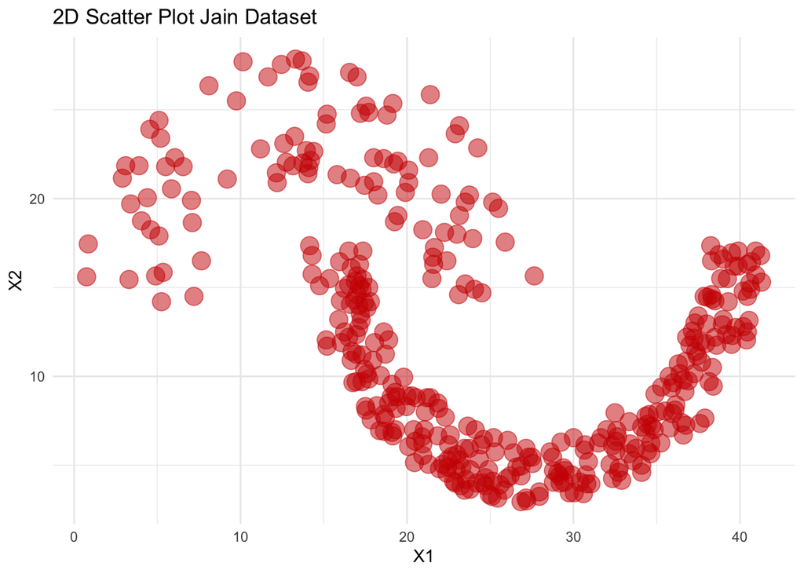

```r
library(caret)
library(mclust)
library(cluster)
library(clue)
library(clusterSim)
library(ggplot2)
library(factoextra)
library(clusterCrit)
library(dbscan)
library(gridExtra)
library(aricode)

# Load and prepare Jain dataset
data <- as.matrix(read.table("~/Downloads/JainData.txt", sep = ","))
X <- data[, -3]
true_labels <- factor(data[, 3])
# Create a data frame from X
df <- data.frame(X1 = X[, 1], X2 = X[, 2])

ggplot(df, aes(x = X1, y = X2)) +

  geom_point(alpha = 0.5, color = "red3", size=5) +
  ggtitle("2D Scatter Plot Jain Dataset") +
  theme_minimal() +  # Minimal theme for cleaner appearance
  theme(legend.position = "none")
```

### K-means Clustering on Jain Dataset

```r
# Align predicted clusters to true labels
map_clusters <- function(true, predicted) {
  tbl <- table(true, predicted)
  if (ncol(tbl) != 2) stop("Only supports 2 clusters")
  if (tbl[1,1] + tbl[2,2] < tbl[1,2] + tbl[2,1]) {
    predicted <- ifelse(predicted == 1, 2, 1)
  }
  return(predicted)
}
```

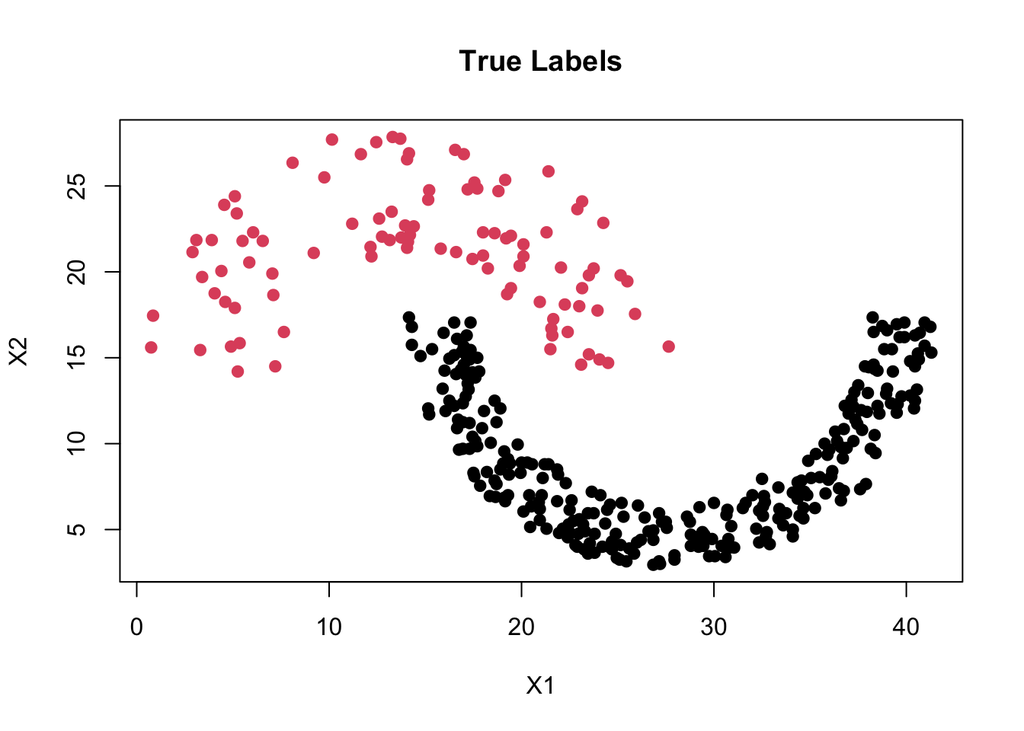

```r
set.seed(25)
k <- 2
n <- nrow(X)
max_iter <- 100

# Step 1: Initialize centers randomly
init_indices <- sample(1:n, k)
centers <- X[init_indices, ]

# Storage
cluster_assignments <- rep(0, n)

for (iter in 1:max_iter) {
  # Step 2: Assign each point to the nearest center
  for (i in 1:n) {
    dists <- apply(centers, 1, function(center) sum((X[i, ] - center)^2))
    cluster_assignments[i] <- which.min(dists)
  }

  # Step 3: Recalculate centers
  new_centers <- matrix(0, nrow = k, ncol = ncol(X))
  for (j in 1:k) {
    points_in_cluster <- X[cluster_assignments == j, , drop = FALSE]
    if (nrow(points_in_cluster) > 0) {
      new_centers[j, ] <- colMeans(points_in_cluster)
    } else {
      new_centers[j, ] <- X[sample(1:n, 1), ]  # Handle empty cluster
    }
  }

  # Step 4: Check for convergence
  if (all(abs(new_centers - centers) < 1e-6)) {
    break
  }
  centers <- new_centers
}
# Map predicted clusters to true labels
assignments_kmeans <- map_clusters(true_labels, cluster_assignments)

# Confusion Matrix
conf_matrix_kmeans <- confusionMatrix(factor(assignments_kmeans), true_labels)

# ARI
ari_kmeans <- adjustedRandIndex(true_labels, assignments_kmeans)

# Silhouette
sil_kmeans <- silhouette(assignments_kmeans, dist(X))
mean_sil_kmeans <- mean(sil_kmeans[, 3])




nmi_kmeans <- NMI(true_labels, assignments_kmeans)

# Plot True Labels
plot(X, col = true_labels, pch = 19, main = "True Labels", xlab = "X1", ylab = "X2")
```

[figure not shown]

```r
# Plot Manual K-means Results
plot(X, col = assignments_kmeans, pch = 19, main = "Manual K-means Clustering", xlab = "X1", ylab = "X2")
points(centers, col = 1:k, pch = 4, cex = 2, lwd = 3)
legend("topright", legend = c("Cluster 1", "Cluster 2"), col = 1:2, pch = 19)

mtext(paste("Parameters: k =", k,
            "| Max Iter =", max_iter,
            "| Seed =", 42,
            "| Silhouette =", round(mean_sil_kmeans, 3),
            "| ARI =", round(ari_kmeans, 3),
            "| NMI =", round(nmi_kmeans, 3)),
      side = 1, line = 4, cex = 0.8)
```

```r
cat("Manual K-means ARI:", round(ari_kmeans, 3), "\n")
```

```
## Manual K-means ARI: 0.324
```

```r
cat("Manual K-means Silhouette Coefficient:", round(mean_sil_kmeans, 3), "\n")
```

```
## Manual K-means Silhouette Coefficient: 0.495
```

```r
cat("Manual K-means NMI:", round(nmi_kmeans, 3), "\n")
```

```
## Manual K-means NMI: 0.337
```

```r
print(conf_matrix_kmeans)
```

```
## Confusion Matrix and Statistics
##
##           Reference
## Prediction   1   2
##          1 197   1
##          2  79  96
##
##                Accuracy : 0.7855
##                  95% CI : (0.7403, 0.8261)
##     No Information Rate : 0.7399
##     P-Value [Acc > NIR] : 0.02403
##
##                   Kappa : 0.558
##
##  Mcnemar's Test P-Value : < 2e-16
##
##             Sensitivity : 0.7138
##             Specificity : 0.9897
##          Pos Pred Value : 0.9949
##          Neg Pred Value : 0.5486
##              Prevalence : 0.7399
##          Detection Rate : 0.5282
##    Detection Prevalence : 0.5308
##       Balanced Accuracy : 0.8517
##
##        'Positive' Class : 1
##
```

**For the Jain dataset, we applied the K-means clustering algorithm and obtained the following results:**

[output not shown]

### K-means + PCA

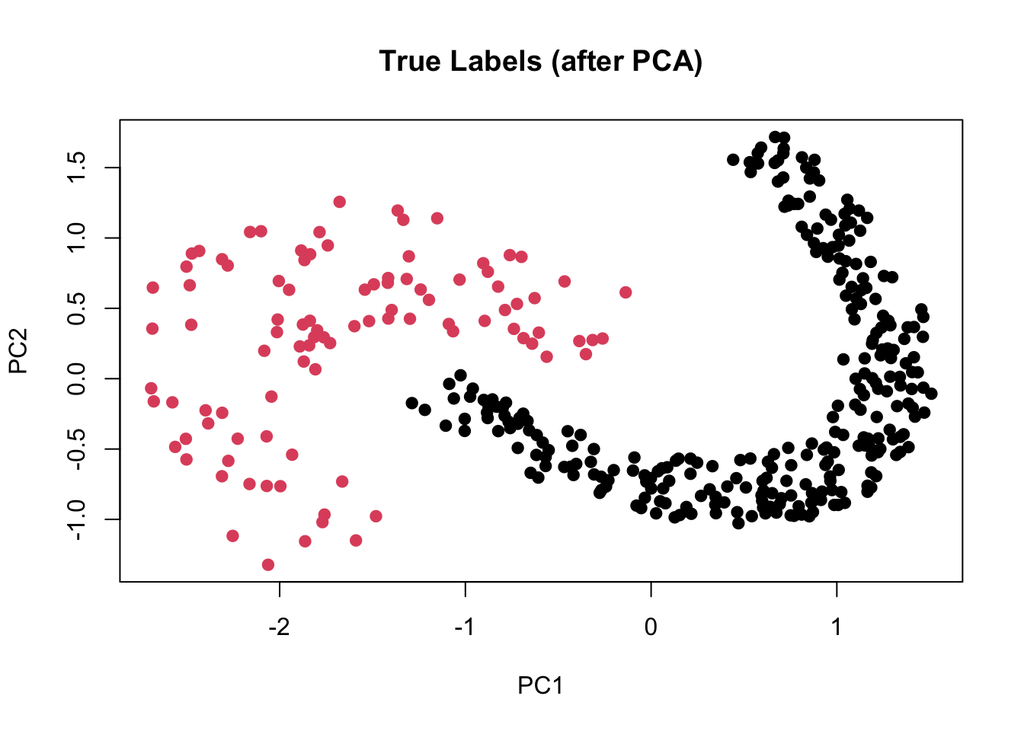

```r
X_scaled <- scale(X)
pca_result <- prcomp(X_scaled)
X_pca <- pca_result$x[, 1:2]

km_pca <- kmeans(X_pca, centers = 2, nstart = 25)
aligned_km_pca <- map_clusters(true_labels, km_pca$cluster)
nmi_km_pca <- NMI(true_labels, aligned_km_pca)
conf_matrix_km_pca <- confusionMatrix(factor(aligned_km_pca), true_labels)
ari_km_pca <- adjustedRandIndex(true_labels, aligned_km_pca)
sil_km_pca <- silhouette(aligned_km_pca, dist(X_pca))
mean_sil_km_pca <- mean(sil_km_pca[, 3])
# Plot True Labels after PCA
plot(X_pca, col = true_labels, pch = 19, main = "True Labels (after PCA)", xlab = "PC1", ylab = "PC2")
```

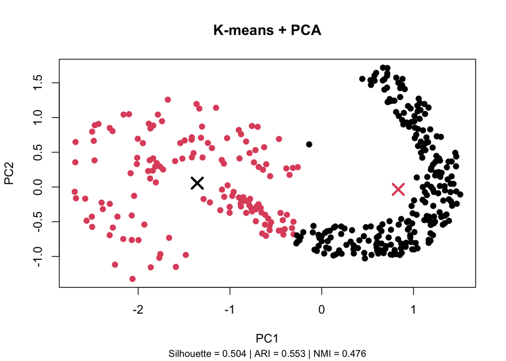

```r
# Plot K-means+PCA Results
plot(X_pca, col = aligned_km_pca, pch = 19, main = "K-means + PCA", xlab = "PC1", ylab = "PC2")
points(km_pca$centers, col = 1:k, pch = 4, cex = 2, lwd = 3)

mtext(paste("Silhouette =", round(mean_sil_km_pca, 3),
            "| ARI =", round(ari_km_pca, 3),
            "| NMI =", round(nmi_km_pca, 3)),
      side = 1, line = 4, cex = 0.8)
```

```r
# Print metrics
cat("K-means + PCA ARI:", round(ari_km_pca, 3), "\n")
```

```
## K-means + PCA ARI: 0.553
```

```r
cat("K-means + PCA Silhouette Coefficient:", round(mean_sil_km_pca, 3), "\n")
```

```
## K-means + PCA Silhouette Coefficient: 0.504
```

```r
print(conf_matrix_km_pca)
```

```
## Confusion Matrix and Statistics
##
##           Reference
## Prediction   1   2
##          1 230   1
##          2  46  96
##
##                Accuracy : 0.874
##                  95% CI : (0.836, 0.9059)
##     No Information Rate : 0.7399
##     P-Value [Acc > NIR] : 1.714e-10
##
##                   Kappa : 0.7154
##
##  Mcnemar's Test P-Value : 1.380e-10
##
##             Sensitivity : 0.8333
##             Specificity : 0.9897
##          Pos Pred Value : 0.9957
##          Neg Pred Value : 0.6761
##              Prevalence : 0.7399
##          Detection Rate : 0.6166
##    Detection Prevalence : 0.6193
##       Balanced Accuracy : 0.9115
##
##        'Positive' Class : 1
##
```

**Even though there are only two dimensions, PCA can still improve clustering because it helps reframe the data in terms of its most important features (principal components), reduces noise and redundancy, and improves how K-means interprets the clusters. Essentially, PCA is helping to better expose the structure in the data that the clustering algorithm can leverage, leading to better results in terms of accuracy, sensitivity, and adjusted Rand index (ARI).**

**The results from normal K-mean is not satisfying so we applied PCA to the K-means clustering algorithm and obtained the following results:**

[output not shown]

### EM on Jain dataset

**We used the EM algorithm with the Gaussian Mixture Model (GMM) to cluster the data as our next algorithm. GMM assumes the data is a mixture of several Gaussian distributions, making it ideal for identifying elliptical clusters. This method provides probabilistic cluster assignments, allowing us to account for uncertainty and overlap in the data.**

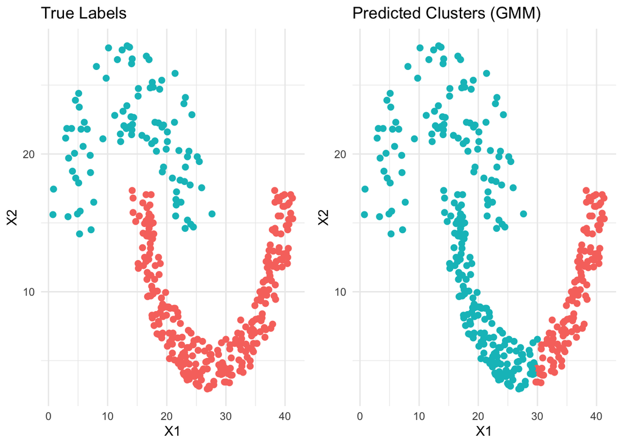

```r
# --- Load Jain Dataset ---
jain_url <- "https://cs.joensuu.fi/sipu/datasets/jain.txt"
jain_data <- read.table(jain_url, header = FALSE)

# --- Separate Features and Labels ---
X <- jain_data[, 1:2]               # Features (X, Y)
true_labels <- as.factor(jain_data[, 3])  # True labels (column 3)

# --- Apply PCA (Optional Step for Higher Dimensionality Datasets) ---
# If you want to apply PCA, it would be especially useful for higher-dimensional data.


# --- EM Clustering (GMM) ---
gmm_model <- Mclust(X, G = 2)  # Using PCA-transformed data for GMM

# --- Get Posterior Probabilities (Uncertainty) ---
posterior_probs <- gmm_model$z  # Posterior probabilities of belonging to each cluster
uncertainty <- 1 - apply(posterior_probs, 1, max)  # Uncertainty is the inverse of max probability

# --- Plotting Uncertainty ---
df_plot <- data.frame(X1 = X[,1], X2 = X[,2], Uncertainty = uncertainty)

# Uncertainty plot (low uncertainty = confident assignment, high uncertainty = more overlap)
uncertainty_plot <- ggplot(df_plot, aes(x = X1, y = X2, color = Uncertainty)) +
  geom_point(size = 2) +
  scale_color_gradient(low = "blue", high = "red") +
  ggtitle("Clustering Uncertainty (GMM)") +
  theme_minimal() +
  theme(legend.position = "right")

# --- Plot True and Predicted Labels for Comparison ---
predicted_clusters <- as.factor(gmm_model$classification)
predicted_clusters <- as.factor(ifelse(predicted_clusters == 1, 2, 1))
df_labels_plot <- data.frame(X1 = X[,1], X2 = X[,2], True_Label = true_labels, Predicted = predicted_clusters)

plot_true <- ggplot(df_labels_plot, aes(x = X1, y = X2, color = True_Label)) +
  geom_point(size = 2) +
  ggtitle("True Labels") +
  theme_minimal() +
  theme(legend.position = "none")

plot_pred <- ggplot(df_labels_plot, aes(x = X1, y = X2, color = Predicted)) +
  geom_point(size = 2) +
  ggtitle("Predicted Clusters (GMM)") +
  theme_minimal() +
  theme(legend.position = "none")

# Arrange the first two plots side by side, leaving the uncertainty plot as a separate plot
grid.arrange(plot_true, plot_pred, ncol = 2)
```

```r
# --- Silhouette Score ---
sil <- silhouette(as.numeric(predicted_clusters), dist(X))
mean_silhouette <- mean(sil[, 3])
cat("Mean Silhouette Score:", round(mean_silhouette, 3), "\n")
```

```
## Mean Silhouette Score: 0.448
```

```r
# --- Confusion Matrix ---
confusion <- confusionMatrix(predicted_clusters, true_labels)
print(confusion)
```

```
## Confusion Matrix and Statistics
##
##           Reference
## Prediction   1   2
##          1 119   0
##          2 157  97
##
##                Accuracy : 0.5791
##                  95% CI : (0.5272, 0.6297)
##     No Information Rate : 0.7399
##     P-Value [Acc > NIR] : 1
##
##                   Kappa : 0.2828
##
##  Mcnemar's Test P-Value : <2e-16
##
##             Sensitivity : 0.4312
##             Specificity : 1.0000
##          Pos Pred Value : 1.0000
##          Neg Pred Value : 0.3819
##              Prevalence : 0.7399
##          Detection Rate : 0.3190
##    Detection Prevalence : 0.3190
##       Balanced Accuracy : 0.7156
##
##        'Positive' Class : 1
##
```

```r
nmi_score <- NMI(true_labels, predicted_clusters)
cat("Normalized Mutual Information (NMI):", round(nmi_score, 3), "\n")
```

```
## Normalized Mutual Information (NMI): 0.192
```

[output not shown]

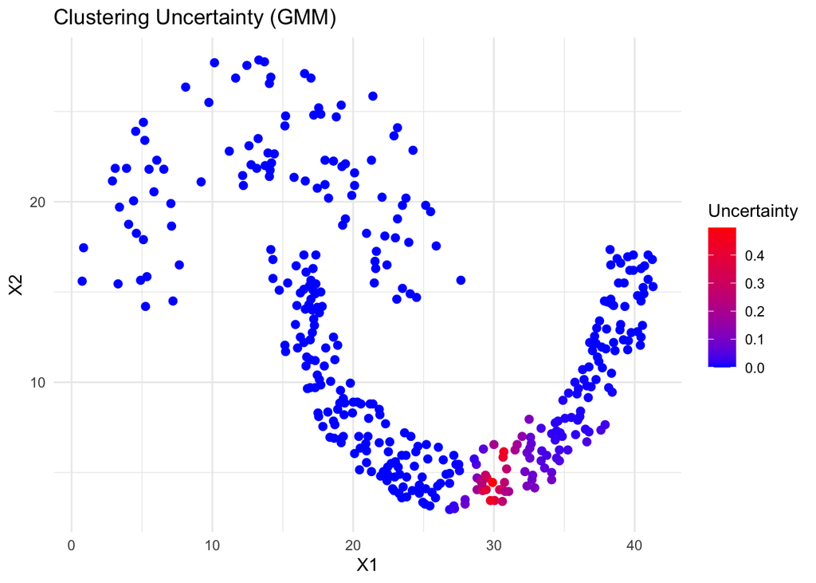

```r
print(uncertainty_plot)
```

**Visualizing the uncertainty**

The uncertainty values highlight regions where the GMM is less confident in cluster assignments, often corresponding to overlaps between Gaussians. This contrasts with hard clustering methods like K-means, which obscure such nuances.

### Conclusion

**K-means is a decent clustering algorithm but could benefit from some optimizations, as evidenced by the moderate ARI and Silhouette Coefficient.**

**Both methods showed excellent specificity, meaning they are both good at identifying the negative class.**

## R15 Dataset

The R15 dataset is a synthetic dataset commonly used for evaluating clustering algorithms. It has the following characteristics:

```
•   Number of Data Points (N): 600
•   Number of Clusters (k): 15
•   Dimensionality (D): 2
```

Unlike the Jain dataset, which has a smaller number of clusters, the R15 dataset features a larger number of clusters, making it an ideal tool for showcasing the ability to handle clustering tasks with varying cluster counts and shapes. This dataset provides a good challenge for testing clustering techniques like DBSCAN, K-means, and others, regardless of the number of clusters or their structure.

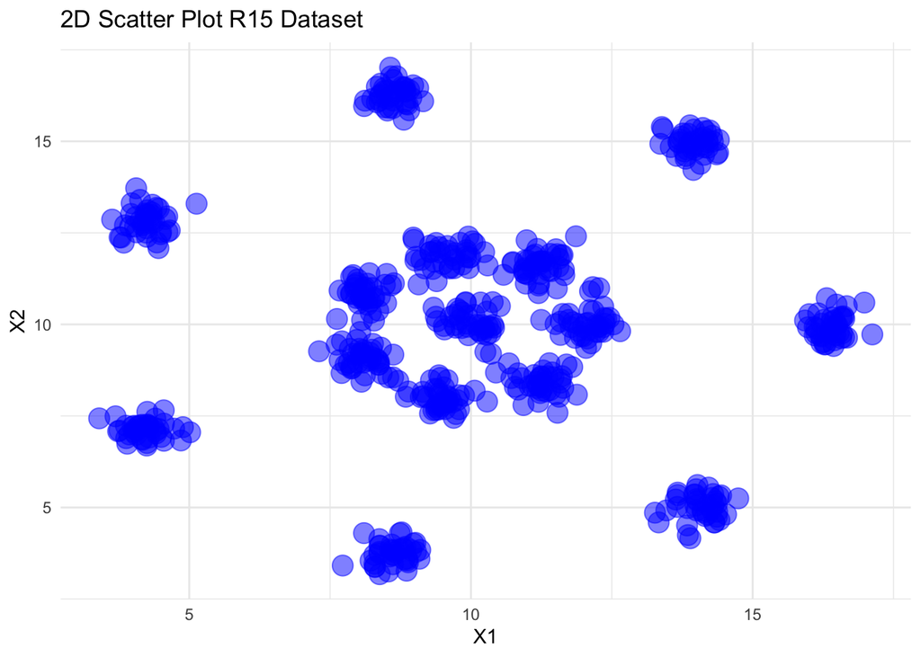

```r
data <- as.matrix(read.table("~/Downloads/R15dataset.txt"))
X <- data[, -3]
true_labels <- data[, 3]
# Create a data frame from X
df <- data.frame(X1 = X[, 1], X2 = X[, 2])

# Create the plot
ggplot(df, aes(x = X1, y = X2)) +
  # Plot points with transparency (alpha controls the fading)
  geom_point(alpha = 0.5, color = "blue", size=5) +
  ggtitle("2D Scatter Plot R15 Dataset") +
  theme_minimal() +  # Minimal theme for cleaner appearance
  theme(legend.position = "none")
```

### K-mean R15

```r
map_clusters <- function(true_labels, predicted_clusters) {
  contingency <- table(true_labels, predicted_clusters)
  mapping <- solve_LSAP(contingency, maximum = TRUE)
  mapped <- mapping[predicted_clusters]
  return(mapped)
}
```

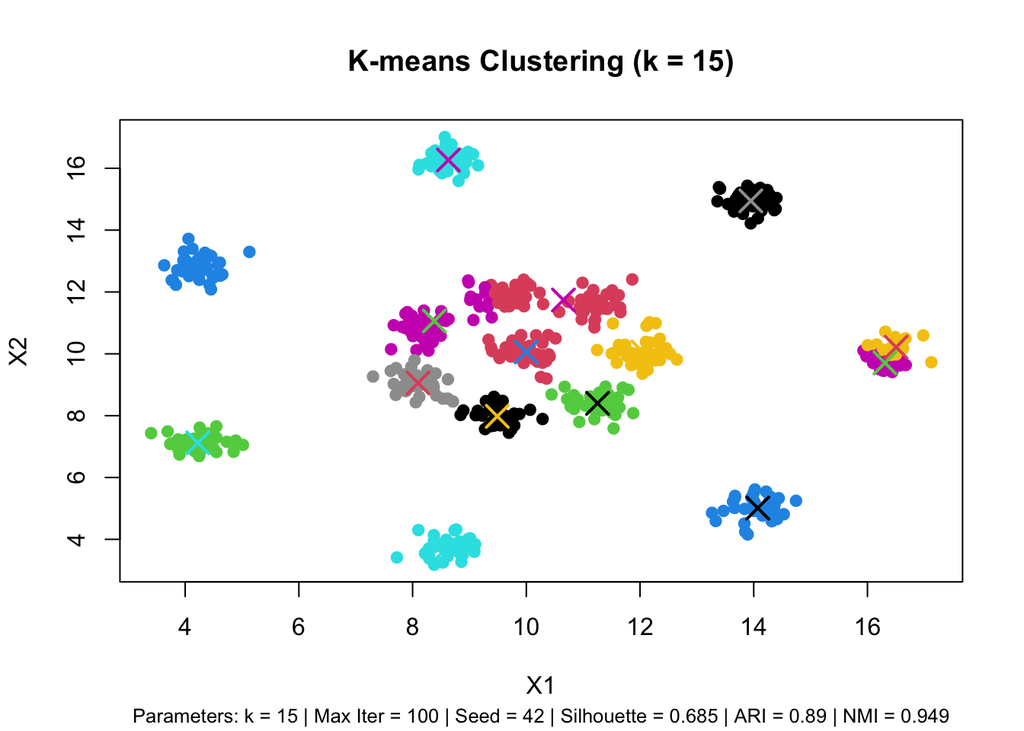

```r
# Manual K-means
set.seed(42)
k <- 15
n <- nrow(X)
max_iter <- 100

init_indices <- sample(1:n, k)
centers <- X[init_indices, ]
cluster_assignments <- rep(0, n)

for (iter in 1:max_iter) {
  # Assign each point to nearest center
  for (i in 1:n) {
    dists <- apply(centers, 1, function(center) sum((X[i, ] - center)^2))
    cluster_assignments[i] <- which.min(dists)
  }

  # Recompute centers
  new_centers <- matrix(0, nrow = k, ncol = ncol(X))
  for (j in 1:k) {
    cluster_points <- X[cluster_assignments == j, , drop = FALSE]
    if (nrow(cluster_points) > 0) {
      new_centers[j, ] <- colMeans(cluster_points)
    } else {
      new_centers[j, ] <- X[sample(1:n, 1), ]
    }
  }

  # Convergence check
  if (all(abs(new_centers - centers) < 1e-6)) break
  centers <- new_centers
}

# Evaluation metrics
assignments_kmeans <- map_clusters(true_labels, cluster_assignments)
ari_kmeans <- adjustedRandIndex(true_labels, assignments_kmeans)
nmi_kmeans <- NMI(true_labels, assignments_kmeans)
sil_kmeans <- silhouette(assignments_kmeans, dist(X))
mean_sil_kmeans <- mean(sil_kmeans[, 3])

# Plot clustering results
palette <- rainbow(k)
plot(X, col = assignments_kmeans, pch = 19, main = "K-means Clustering (k = 15)", xlab = "X1", ylab = "X2")
points(centers, col = 1:k, pch = 4, cex = 2, lwd = 2)

mtext(paste("Parameters: k =", k,
            "| Max Iter =", max_iter,
            "| Seed =", 42,
            "| Silhouette =", round(mean_sil_kmeans, 3),
            "| ARI =", round(ari_kmeans, 3),
            "| NMI =", round(nmi_kmeans, 3)),
      side = 1, line = 4, cex = 0.8)
```

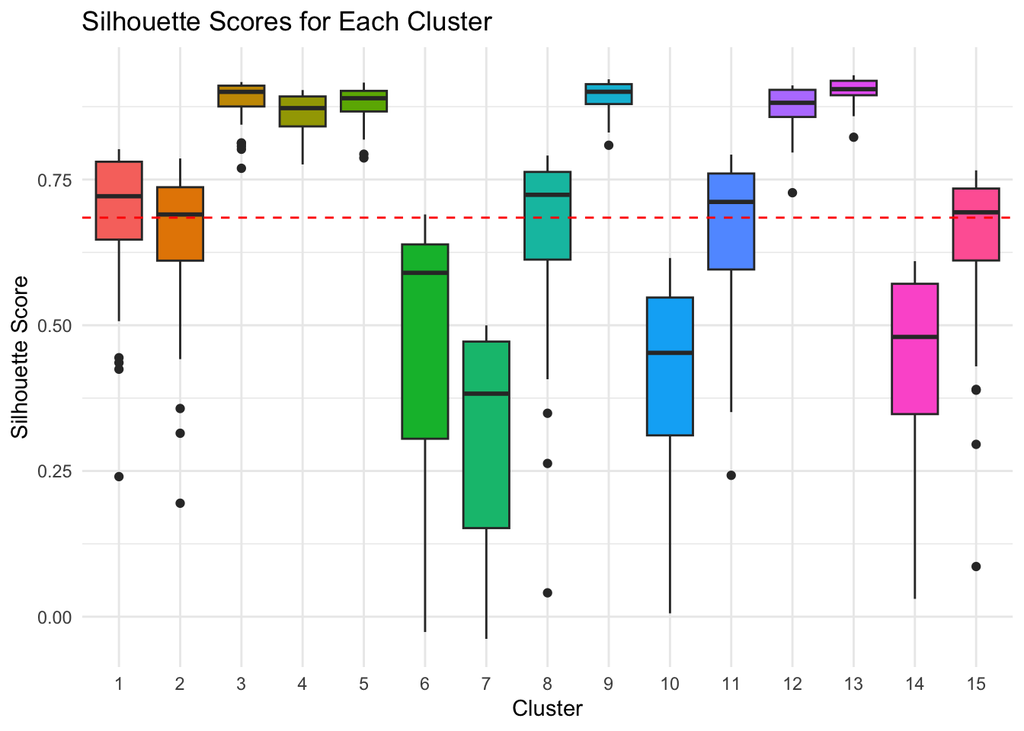

```r
# Plot Silhouette Scores for Clusters
sil_score <- sil_kmeans[, 3]  # Silhouette scores for each data point
sil_df <- data.frame(Cluster = factor(assignments_kmeans), Silhouette = sil_score)

# Plot the silhouette scores for each cluster
library(ggplot2)
ggplot(sil_df, aes(x = Cluster, y = Silhouette, fill = Cluster)) +
  geom_boxplot() +
  geom_hline(yintercept = mean_sil_kmeans, color = "red", linetype = "dashed") +
  ggtitle("Silhouette Scores for Each Cluster") +
  xlab("Cluster") + ylab("Silhouette Score") +
  theme_minimal() +
  theme(legend.position = "none")
```

**The Manual K-means clustering on the R15 dataset achieved strong results:**

```
• ARI = 0.89: This indicates a high agreement between the predicted clusters and true labels, reflecting accurate clustering.

• Silhouette Coefficient = 0.685: This suggests moderate separation between clusters, with some potential overlap.

• NMI = 0.949: This indicates an excellent level of shared information between the predicted clusters and the true labels, showing that the clustering captured almost all of the underlying structure.
```

**The clustering results show that the Manual K-means algorithm is well-suited for the R15 dataset, providing a strong clustering performance with high Adjusted Rand Index and good Silhouette Coefficient scores. However, there is always room for improvement, especially when working with more complex data or when trying to achieve near-perfect clustering.**

### DBSCAN R15

**We apply DBSCAN to the R15 dataset to uncover clusters and detect outliers without predefining the number of clusters. DBSCAN is chosen for its ability to handle data with varying densities and noise, also for trying different methods and see their results**

```r
data <- as.matrix(read.table("~/Downloads/R15dataset.txt"))
X <- data[, -3]
true_labels <- data[, 3]

# --- DBSCAN Clustering ---
eps_value <- 0.4
minPts_value <- 8
dbscan_result <- dbscan(X, eps = eps_value, minPts = minPts_value)

df_true <- data.frame(X1 = X[,1], X2 = X[,2], Label = as.factor(true_labels))
df_dbscan <- data.frame(X1 = X[,1], X2 = X[,2], Label = as.factor(dbscan_result$cluster))

# --- Metrics Calculation ---
# Filter out noise points (cluster = 0)
valid_indices <- dbscan_result$cluster != 0
true_f <- factor(true_labels[valid_indices])
pred_f <- factor(dbscan_result$cluster[valid_indices], levels = levels(true_f))

# Confusion Matrix
conf_matrix_dbscan <- confusionMatrix(pred_f, true_f)


# Silhouette Score
sil_dbscan <- silhouette(dbscan_result$cluster[valid_indices], dist(X[valid_indices, ]))
mean_sil_dbscan <- mean(sil_dbscan[, 3])
cat("DBSCAN Silhouette Score:", round(mean_sil_dbscan, 3), "\n")
```

```
## DBSCAN Silhouette Score: 0.767
```

```r
# Adjusted Rand Index (ARI)
ari_dbscan <- adjustedRandIndex(true_labels[valid_indices], dbscan_result$cluster[valid_indices])
cat("Adjusted Rand Index (ARI):", round(ari_dbscan, 3), "\n")
```

```
## Adjusted Rand Index (ARI): 0.992
```

```r
# Normalized Mutual Information (NMI)
nmi_dbscan <- NMI(true_labels[valid_indices], dbscan_result$cluster[valid_indices])
cat("Normalized Mutual Information (NMI):", round(nmi_dbscan, 3), "\n")
```

```
## Normalized Mutual Information (NMI): 0.994
```

```r
# Number of Noise Points
num_noise_points <- sum(dbscan_result$cluster == 0)
cat("Number of noise points:", num_noise_points, "\n")
```

```
## Number of noise points: 23
```

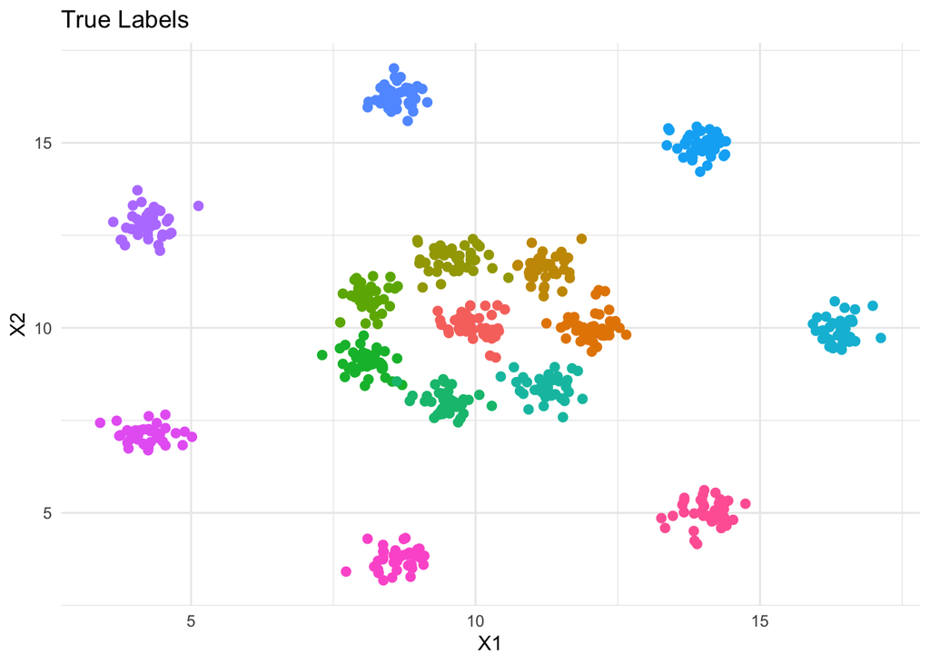

```r
# Plot True Labels
plot_true <- ggplot(df_true, aes(x = X1, y = X2, color = Label)) +
  geom_point(size = 2) +
  ggtitle("True Labels") +
  scale_color_discrete(name = "True Labels") +
  theme_minimal() +
  theme(legend.position = "none")

# Plot DBSCAN Clustering Results with Parameters and Metrics
plot_dbscan <- ggplot(df_dbscan, aes(x = X1, y = X2, color = Label)) +
  geom_point(size = 2) +
  ggtitle("DBSCAN Clustering") +
  scale_color_discrete(name = "DBSCAN Clusters") +
  theme_minimal() +
  theme(legend.position = "none") +
  annotate("text", x = Inf, y = Inf, hjust = 1.1, vjust = 1.5, size = 4, color = "black",
           label = paste("eps =", eps_value,
                         "\nminPts =", minPts_value,
                         "\nSilhouette =", round(mean_sil_dbscan, 3),
                         "\nARI =", round(ari_dbscan, 3),
                         "\nNMI =", round(nmi_dbscan, 3)))

# Side-by-side plots
print(plot_true)
```

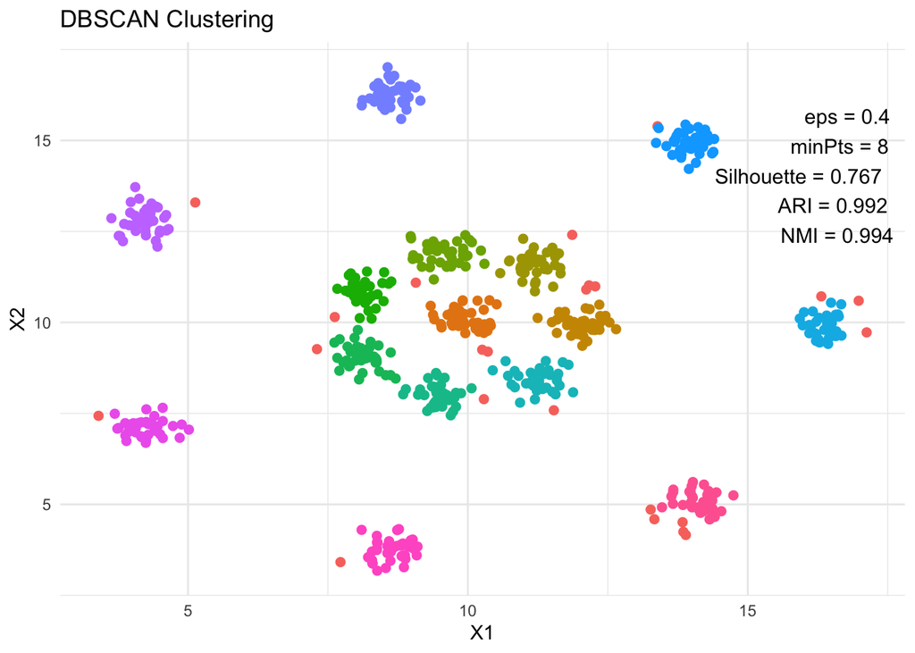

```r
print(plot_dbscan)
```

[output not shown]

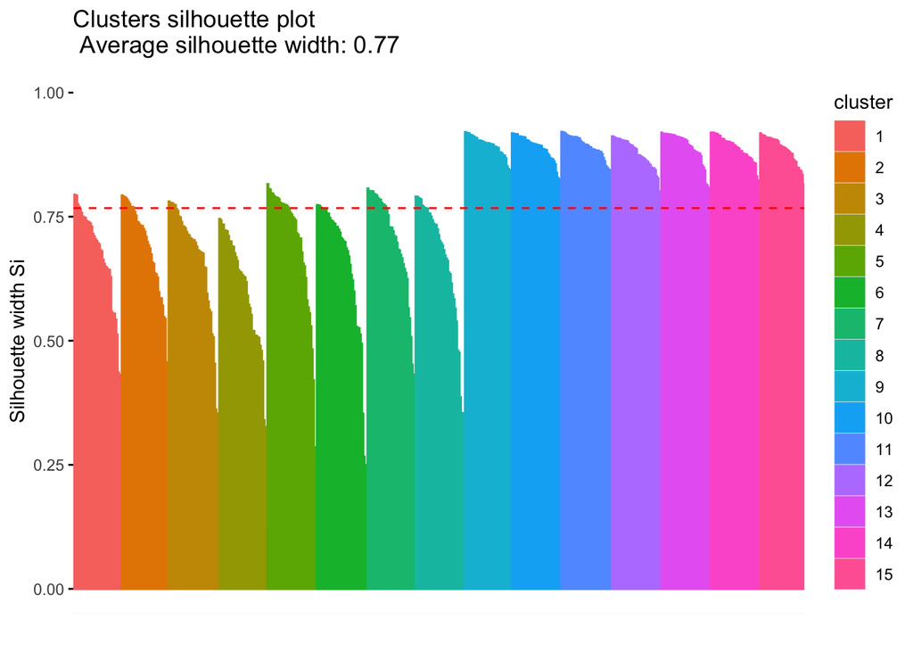

```r
# --- Silhouette Plot ---
fviz_silhouette(sil_dbscan)
```

```r
print(conf_matrix_dbscan)
```

```
## Confusion Matrix and Statistics
##
##           Reference
## Prediction  1  2  3  4  5  6  7  8  9 10 11 12 13 14 15
##         1  38  0  0  0  0  0  0  0  0  0  0  0  0  0  0
##         2   0 37  0  0  0  0  0  0  0  0  0  0  0  0  0
##         3   0  0 39  1  0  0  0  0  0  0  0  0  0  0  0
##         4   0  0  0 38  0  0  0  0  0  0  0  0  0  0  0
##         5   0  0  0  0 39  0  0  0  0  0  0  0  0  0  0
##         6   0  0  0  0  0 39  1  0  0  0  0  0  0  0  0
##         7   0  0  0  0  0  0 38  0  0  0  0  0  0  0  0
##         8   0  0  0  0  0  0  0 39  0  0  0  0  0  0  0
##         9   0  0  0  0  0  0  0  0 37  0  0  0  0  0  0
##         10  0  0  0  0  0  0  0  0  0 39  0  0  0  0  0
##         11  0  0  0  0  0  0  0  0  0  0 40  0  0  0  0
##         12  0  0  0  0  0  0  0  0  0  0  0 39  0  0  0
##         13  0  0  0  0  0  0  0  0  0  0  0  0 39  0  0
##         14  0  0  0  0  0  0  0  0  0  0  0  0  0 39  0
##         15  0  0  0  0  0  0  0  0  0  0  0  0  0  0 35
##
## Overall Statistics
##
##                Accuracy : 0.9965
##                  95% CI : (0.9875, 0.9996)
##     No Information Rate : 0.0693
##     P-Value [Acc > NIR] : < 2.2e-16
##
##                   Kappa : 0.9963
##
##  Mcnemar's Test P-Value : NA
##
## Statistics by Class:
##
##                      Class: 1 Class: 2 Class: 3 Class: 4 Class: 5 Class: 6
## Sensitivity           1.00000  1.00000  1.00000  0.97436  1.00000  1.00000
## Specificity           1.00000  1.00000  0.99814  1.00000  1.00000  0.99814
## Pos Pred Value        1.00000  1.00000  0.97500  1.00000  1.00000  0.97500
## Neg Pred Value        1.00000  1.00000  1.00000  0.99814  1.00000  1.00000
## Prevalence            0.06586  0.06412  0.06759  0.06759  0.06759  0.06759
## Detection Rate        0.06586  0.06412  0.06759  0.06586  0.06759  0.06759
## Detection Prevalence  0.06586  0.06412  0.06932  0.06586  0.06759  0.06932
## Balanced Accuracy     1.00000  1.00000  0.99907  0.98718  1.00000  0.99907
##                      Class: 7 Class: 8 Class: 9 Class: 10 Class: 11 Class: 12
## Sensitivity           0.97436  1.00000  1.00000   1.00000   1.00000   1.00000
## Specificity           1.00000  1.00000  1.00000   1.00000   1.00000   1.00000
## Pos Pred Value        1.00000  1.00000  1.00000   1.00000   1.00000   1.00000
## Neg Pred Value        0.99814  1.00000  1.00000   1.00000   1.00000   1.00000
## Prevalence            0.06759  0.06759  0.06412   0.06759   0.06932   0.06759
## Detection Rate        0.06586  0.06759  0.06412   0.06759   0.06932   0.06759
## Detection Prevalence  0.06586  0.06759  0.06412   0.06759   0.06932   0.06759
## Balanced Accuracy     0.98718  1.00000  1.00000   1.00000   1.00000   1.00000
##                      Class: 13 Class: 14 Class: 15
## Sensitivity            1.00000   1.00000   1.00000
## Specificity            1.00000   1.00000   1.00000
## Pos Pred Value         1.00000   1.00000   1.00000
## Neg Pred Value         1.00000   1.00000   1.00000
## Prevalence             0.06759   0.06759   0.06066
## Detection Rate         0.06759   0.06759   0.06066
## Detection Prevalence   0.06759   0.06759   0.06066
## Balanced Accuracy      1.00000   1.00000   1.00000
```

**Confusion Matrix:** • The confusion matrixprovided reflects the prediction accuracy for points that are assigned to a cluster. Since outliers (i.e., noise points) are not included in the confusion matrix, the results show only the points that were successfully clustered. • High accuracy: The model is performing exceptionally well with an accuracy of 99.65%. This suggests that most of the points (those not classified as noise) are being clustered correctly.

**Outliers:** • The number of noise points is 23. These are the points that DBSCAN couldn’t assign to any cluster because they were too far from other data points. While these points are excluded from the confusion matrix, they are still important when evaluating clustering quality.

**Adjusted Rand Index (ARI):** • The ARI of 0.992 is excellent. It means the DBSCAN clustering is very similar to the true cluster structure. The ARI takes into account the similarity between predicted clusters and true labels, adjusted for chance, and an ARI score close to 1 indicates near-perfect clustering.

**Silhouette Score:** • The Silhouette score of 0.767 is a strong indicator of how well the clusters are formed, showing good separation and compactness for the clustered points

**Normalized Mutual Information (NMI) :** • The NMI of 0.994 is excellent. This indicates an extremely high mutual dependence between the true labels and the predicted clusters, confirming that the clustering preserved almost all the original label information.

**Class-Specific Metrics:** • The sensitivity, specificity, and positive/negative predictive values are all very high across the different clusters. This indicates that the model is correctly identifying most points from each class without misclassification. • The balanced accuracy for each class is also near perfect (close to 1), which is another sign of good performance across all clusters.

### Conclusion

**The Manual K-means algorithm achieved strong clustering performance on the R15 dataset, with high ARI, NMI, and a good Silhouette score. It demonstrated a strong ability to separate clusters, although some minor overlap was observed, suggesting there is still room for optimization, especially in more complex scenarios.**

**DBSCAN outperformed Manual K-means, delivering near-perfect clustering results with higher ARI, NMI, and a better Silhouette score. Its ability to automatically detect clusters of varying densities without needing to predefine the number of clusters proved highly effective, and it successfully identified outliers as noise points.**

**Overall, while Manual K-means provided a solid baseline with good clustering quality, DBSCAN proved to be more robust and adaptive for the R15 dataset, especially when dealing with noise and complex cluster structures.**